# bhavik

```python
import nltk
nltk.download()
```

```
showing info https://raw.githubusercontent.com/nltk/nltk_data/gh-pages/index.xml
```

```python
from nltk.book import *
```

```
*** Introductory Examples for the NLTK Book ***
Loading text1, ..., text9 and sent1, ..., sent9
Type the name of the text or sentence to view it.
Type: 'texts()' or 'sents()' to list the materials.
text1: Moby Dick by Herman Melville 1851
text2: Sense and Sensibility by Jane Austen 1811
text3: The Book of Genesis
text4: Inaugural Address Corpus
text5: Chat Corpus
text6: Monty Python and the Holy Grail
text7: Wall Street Journal
text8: Personals Corpus
text9: The Man Who Was Thursday by G . K . Chesterton 1908
```

```python
 text1.concordance("monstrous")
```

```
Displaying 11 of 11 matches:
ong the former , one was of a most monstrous size . ... This came towards us ,
ON OF THE PSALMS . " Touching that monstrous bulk of the whale or ork we have r
ll over with a heathenish array of monstrous clubs and spears . Some were thick
d as you gazed , and wondered what monstrous cannibal and savage could ever hav
that has survived the flood ; most monstrous and most mountainous ! That Himmal
they might scout at Moby Dick as a monstrous fable , or still worse and more de
th of Radney .'" CHAPTER 55 Of the Monstrous Pictures of Whales . I shall ere l
ing Scenes . In connexion with the monstrous pictures of whales , I am strongly
ere to enter upon those still more monstrous stories of them which are to be fo
ght have been rummaged out of this monstrous cabinet there is no telling . But
of Whale - Bones ; for Whales of a monstrous size are oftentimes cast up dead u
```

```python
text1.similar("monstrous")
```

```
true contemptible christian abundant few part mean careful puzzled
mystifying passing curious loving wise doleful gamesome singular
delightfully perilous fearless
```

```python
text2.similar("monstrous")
```

```
very so exceedingly heartily a as good great extremely remarkably
sweet vast amazingly
```

```python
text2.common_contexts(["monstrous", "very"])
```

```
am_glad a_pretty a_lucky is_pretty be_glad
```

```
Matplotlib is building the font cache; this may take a moment.
```

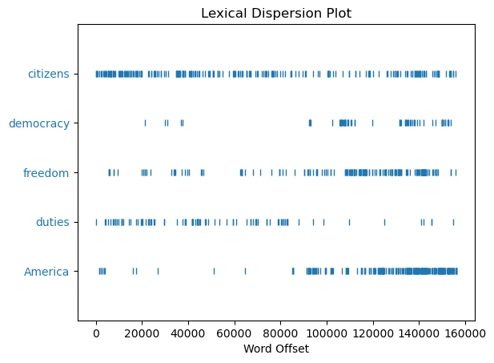

```python
text4.dispersion_plot(["citizens", "democracy", "freedom", "duties", "America"])
```

```python
 text3.generate()
```

```
Building ngram index...
```

```
laid by her , and said unto Cain , Where art thou , and said , Go to ,
I will not do it for ten ' s sons ; we dreamed each man according to
their generatio the firstborn said unto Laban , Because I said , Nay ,
but Sarah shall her name be . , duke Elah , duke Shobal , and Akan .
and looked upon my affliction . Bashemath Ishmael ' s blood , but Isra
for as a prince hast thou found of all the cattle in the valley , and
the wo The
```

```
"laid by her , and said unto Cain , Where art thou , and said , Go to ,\nI will not do it for ten ' s sons ; we dreamed each man according to\ntheir generatio the firstborn said unto Laban , Because I said , Nay ,\nbut Sarah shall her name be . , duke Elah , duke Shobal , and Akan .\nand looked upon…
```

```python
len(text3)
```

```
44764
```

```python
len(text2)
```

```
141576
```

```python
sorted(set(text3))
```

```
['!',
 "'",
 '(',
 ')',
 ',',
 ',)',
 '.',
 '.)',
 ':',
 ';',
 ';)',
 '?',
 '?)',
 'A',
 'Abel',
 'Abelmizraim',
 'Abidah',
 'Abide',
 'Abimael',
 'Abimelech',
 'Abr',
 'Abrah',
 'Abraham',
 'Abram',
 'Accad',
 'Achbor',
 'Adah',
 'Adam',
 'Adbeel',
 'Admah',
 'Adullamite',
 'After',
 'Aholibamah',
 'Ahuzzath',
 'Ajah',
 'Akan',
 'All',
 'Allonbachuth',
 'Almighty',
 'Almodad',
```

[output cut: 946 more lines]

```
 'clean',
 'clear',
 'cleave',
 'clo',
 'closed',
 'clothed',
 'clothes',
 'cloud',
 'clusters',
 'co',
 'coat',
 'coats',
 'coffin',
 'cold',
 ...]
```

```python
len(set(text3))
```

```
2789
```

```python
 from __future__ import division
```

```python
 len(text3) / len(set(text3))
```

```
16.050197203298673
```

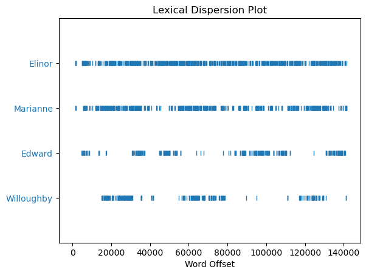

```python
text2.dispersion_plot(["Elinor","Marianne","Edward","Willoughby"])
```

```python
len(text5)
```

```
45010
```

```python
len (set(text3))
```

```
2789
```

```python
text5.collocation_list()
```

```
[('wanna', 'chat'),
 ('PART', 'JOIN'),
 ('MODE', '#14-19teens'),
 ('JOIN', 'PART'),
 ('PART', 'PART'),
 ('cute.-ass', 'MP3'),
 ('MP3', 'player'),
 ('JOIN', 'JOIN'),
 ('times', '.. .'),
 ('ACTION', 'watches'),
 ('guys', 'wanna'),
 ('song', 'lasts'),
 ('last', 'night'),
 ('ACTION', 'sits'),
 ('-...)...-', 'S.M.R.'),
 ('Lime', 'Player'),
 ('Player', '12%'),
 ('dont', 'know'),
 ('lez', 'gurls'),
 ('long', 'time')]
```

```python
text1.vocab()
```

```
FreqDist({',': 18713, 'the': 13721, '.': 6862, 'of': 6536, 'and': 6024, 'a': 4569, 'to': 4542, ';': 4072, 'in': 3916, 'that': 2982, ...})
```

```python
 fdist1 = FreqDist(text1)
```

```python
 fdist1
```

```
FreqDist({',': 18713, 'the': 13721, '.': 6862, 'of': 6536, 'and': 6024, 'a': 4569, 'to': 4542, ';': 4072, 'in': 3916, 'that': 2982, ...})
```

```python
vocabulary1 = fdist1.keys()
```

```python
 fdist1['whale']
```

```
906
```

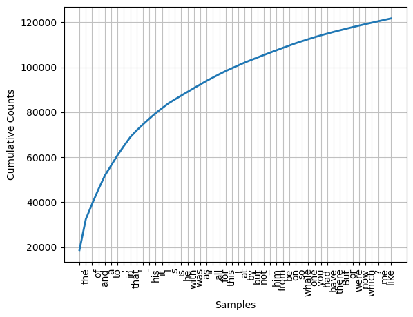

```python
fdist1.plot(50, cumulative=True)
```

```python
import nltk
nltk.corpus.gutenberg.fileids()
```

```
['austen-emma.txt',
 'austen-persuasion.txt',
 'austen-sense.txt',
 'bible-kjv.txt',
 'blake-poems.txt',
 'bryant-stories.txt',
 'burgess-busterbrown.txt',
 'carroll-alice.txt',
 'chesterton-ball.txt',
 'chesterton-brown.txt',
 'chesterton-thursday.txt',
 'edgeworth-parents.txt',
 'melville-moby_dick.txt',
 'milton-paradise.txt',
 'shakespeare-caesar.txt',
 'shakespeare-hamlet.txt',
 'shakespeare-macbeth.txt',
 'whitman-leaves.txt']
```

```python
import nltk
nltk.download()
```

```
showing info https://raw.githubusercontent.com/nltk/nltk_data/gh-pages/index.xml
```

```
True
```

```python
from nltk.book import *
```

```python
import nltk
nltk.download()
```

```
showing info https://raw.githubusercontent.com/nltk/nltk_data/gh-pages/index.xml
```

```python
from nltk.book import *
```

```python
from nltk.book import *
```

```
*** Introductory Examples for the NLTK Book ***
Loading text1, ..., text9 and sent1, ..., sent9
Type the name of the text or sentence to view it.
Type: 'texts()' or 'sents()' to list the materials.
text1: Moby Dick by Herman Melville 1851
text2: Sense and Sensibility by Jane Austen 1811
text3: The Book of Genesis
text4: Inaugural Address Corpus
text5: Chat Corpus
text6: Monty Python and the Holy Grail
text7: Wall Street Journal
text8: Personals Corpus
text9: The Man Who Was Thursday by G . K . Chesterton 1908
```

```python
 text3.generate()
```

```
Building ngram index...
```

```
laid by her , and said unto Cain , Where art thou , and said , Go to ,
I will not do it for ten ' s sons ; we dreamed each man according to
their generatio the firstborn said unto Laban , Because I said , Nay ,
but Sarah shall her name be . , duke Elah , duke Shobal , and Akan .
and looked upon my affliction . Bashemath Ishmael ' s blood , but Isra
for as a prince hast thou found of all the cattle in the valley , and
the wo The
```

```
"laid by her , and said unto Cain , Where art thou , and said , Go to ,\nI will not do it for ten ' s sons ; we dreamed each man according to\ntheir generatio the firstborn said unto Laban , Because I said , Nay ,\nbut Sarah shall her name be . , duke Elah , duke Shobal , and Akan .\nand looked upon…
```

```python
 len(text3)
```

```
44764
```

```python
 sorted(set(text3))
```

```
['!',
 "'",
 '(',
 ')',
 ',',
 ',)',
 '.',
 '.)',
 ':',
 ';',
 ';)',
 '?',
 '?)',
 'A',
 'Abel',
 'Abelmizraim',
 'Abidah',
 'Abide',
 'Abimael',
 'Abimelech',
 'Abr',
 'Abrah',
 'Abraham',
 'Abram',
 'Accad',
 'Achbor',
 'Adah',
 'Adam',
 'Adbeel',
 'Admah',
 'Adullamite',
 'After',
 'Aholibamah',
 'Ahuzzath',
 'Ajah',
 'Akan',
 'All',
 'Allonbachuth',
 'Almighty',
 'Almodad',
```

[output cut: 946 more lines]

```
 'clean',
 'clear',
 'cleave',
 'clo',
 'closed',
 'clothed',
 'clothes',
 'cloud',
 'clusters',
 'co',
 'coat',
 'coats',
 'coffin',
 'cold',
 ...]
```

```python
from __future__ import division
len(text3) / len(set(text3))
```

```
16.050197203298673
```

```python
pip install nltk
```

```python
nltk.download('punkt')
```

```
True
```

```python
phrase = ["Bhavik", "Kumar", "Patel", "learning", "Python", "NLTK"]
```

```python
print(phrase)
```

```
['Bhavik', 'Kumar', 'Patel', 'learning', 'Python', 'NLTK']
```

```python
new_words = ["in", "Jupyter", "Notebook"]
phrase_added = phrase + new_words
```

```python
print(phrase_added)
```

```
['Bhavik', 'Kumar', 'Patel', 'learning', 'Python', 'NLTK', 'in', 'Jupyter', 'Notebook']
```

```python
phrase_removed = phrase.copy()
phrase_removed.remove("Kumar")
```

```python
print(phrase_removed)
```

```
['Bhavik', 'Patel', 'learning', 'Python', 'NLTK']
```

```python
phrase_removed = [word for word in phrase if word != "Kumar"]
print(phrase_removed)
```

```
['Bhavik', 'Patel', 'learning', 'Python', 'NLTK']
```

```python
phrase_multiplied = phrase * 2
```

```python
print(phrase_multiplied)
```

```
['Bhavik', 'Kumar', 'Patel', 'learning', 'Python', 'NLTK', 'Bhavik', 'Kumar', 'Patel', 'learning', 'Python', 'NLTK']
```

```python
print(phrase[0])   # First word
print(phrase[1])   # Second word
print(phrase[-1])  # Last word
```

```
Bhavik
Kumar
NLTK
```

```python
print(phrase[0:3])   # First, middle, last name
print(phrase[3:])    # Words after name
```

```
['Bhavik', 'Kumar', 'Patel']
['learning', 'Python', 'NLTK']
```

```python
sorted_phrase = sorted(phrase)
print(sorted_phrase)
```

```
['Bhavik', 'Kumar', 'NLTK', 'Patel', 'Python', 'learning']
```

```python
phrase.sort()
print(phrase)
```

```
['Bhavik', 'Kumar', 'NLTK', 'Patel', 'Python', 'learning']
```

```python
from nltk.probability import FreqDist
fdist = FreqDist(phrase)
print(fdist)
```

```
<FreqDist with 6 samples and 6 outcomes>
```

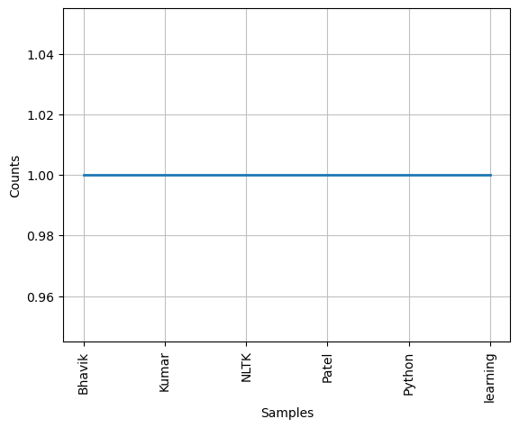

```python
fdist.plot()
```

```python
import nltk
from nltk.corpus import gutenberg
```

```python
nltk.download('gutenberg')
```

```
True
```

```python
persuasion = gutenberg.words('austen-persuasion.txt')
```

```python
len(persuasion)
```

```
98171
```

```python
len(set(persuasion))
```

```
6132
```

```python
len(set(persuasion)) / len(persuasion)
```

```
0.062462437990852694
```

```python
nltk.download('state_union')
```

```
True
```

```python
import nltk
from nltk.corpus import state_union
```

```python
nltk.download('state_union')
```

```
True
```

```python
state_union.fileids()
```

```
['1945-Truman.txt',
 '1946-Truman.txt',
 '1947-Truman.txt',
 '1948-Truman.txt',
 '1949-Truman.txt',
 '1950-Truman.txt',
 '1951-Truman.txt',
 '1953-Eisenhower.txt',
 '1954-Eisenhower.txt',
 '1955-Eisenhower.txt',
 '1956-Eisenhower.txt',
 '1957-Eisenhower.txt',
 '1958-Eisenhower.txt',
 '1959-Eisenhower.txt',
 '1960-Eisenhower.txt',
 '1961-Kennedy.txt',
 '1962-Kennedy.txt',
 '1963-Johnson.txt',
 '1963-Kennedy.txt',
 '1964-Johnson.txt',
 '1965-Johnson-1.txt',
 '1965-Johnson-2.txt',
 '1966-Johnson.txt',
 '1967-Johnson.txt',
 '1968-Johnson.txt',
 '1969-Johnson.txt',
 '1970-Nixon.txt',
 '1971-Nixon.txt',
 '1972-Nixon.txt',
 '1973-Nixon.txt',
 '1974-Nixon.txt',
 '1975-Ford.txt',
 '1976-Ford.txt',
 '1977-Ford.txt',
 '1978-Carter.txt',
 '1979-Carter.txt',
 '1980-Carter.txt',
 '1981-Reagan.txt',
 '1982-Reagan.txt',
 '1983-Reagan.txt',
```

[output cut: 10 more lines]

```
 '1993-Clinton.txt',
 '1994-Clinton.txt',
 '1995-Clinton.txt',
 '1996-Clinton.txt',
 '1997-Clinton.txt',
 '1998-Clinton.txt',
 '1999-Clinton.txt',
 '2000-Clinton.txt',
 '2001-GWBush-1.txt',
 '2001-GWBush-2.txt',
 '2002-GWBush.txt',
 '2003-GWBush.txt',
 '2004-GWBush.txt',
 '2005-GWBush.txt',
 '2006-GWBush.txt']
```

```python
from nltk import FreqDist

targets = ['men', 'women', 'people']

for fileid in state_union.fileids():
    words = state_union.words(fileid)
    fdist = FreqDist(w.lower() for w in words)

    print(fileid)
    for word in targets:
        print(f"  {word}: {fdist[word]}")
```

```
1945-Truman.txt
  men: 2
  women: 2
  people: 10
1946-Truman.txt
  men: 12
  women: 7
  people: 49
1947-Truman.txt
  men: 7
  women: 2
  people: 12
1948-Truman.txt
  men: 5
  women: 1
  people: 22
1949-Truman.txt
  men: 2
  women: 1
  people: 15
1950-Truman.txt
  men: 6
  women: 2
  people: 15
1951-Truman.txt
  men: 8
  women: 2
  people: 10
1953-Eisenhower.txt
  men: 3
  women: 0
  people: 17
1954-Eisenhower.txt
  men: 2
  women: 0
  people: 15
1955-Eisenhower.txt
  men: 4
  women: 0
  people: 26
```

[output cut: 205 more lines]

```
  men: 6
  women: 4
  people: 33
2004-GWBush.txt
  men: 7
  women: 8
  people: 21
2005-GWBush.txt
  men: 8
  women: 11
  people: 18
2006-GWBush.txt
  men: 7
  women: 7
  people: 22
```

```python
from nltk import ConditionalFreqDist

cfd = ConditionalFreqDist(
    (fileid[:4], w.lower())
    for fileid in state_union.fileids()
    for w in state_union.words(fileid)
    if w.lower() in ['men', 'women', 'people']
)

cfd
```

```
<ConditionalFreqDist with 61 conditions>
```

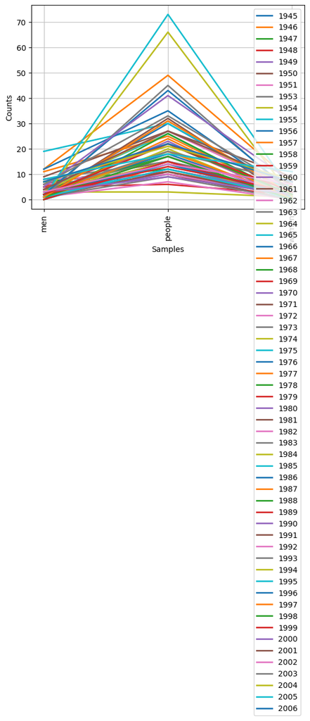

```python
cfd.plot()
```

```python
import nltk
from nltk.corpus import names
from nltk import ConditionalFreqDist
```

```python
nltk.download('names')
```

```
True
```

```python
cfd = ConditionalFreqDist(
    (gender, name[0])
    for gender in names.fileids()
    for name in names.words(gender)
)
```

```python
cfd.conditions()
```

```
['female.txt', 'male.txt']
```

```python
cfd['male']['A']
cfd['female']['A']
```

```
0
```

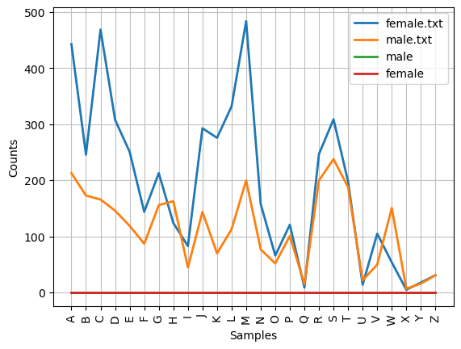

```python
cfd.plot()
```

```python
cfd.tabulate()
```

```
             A   B   C   D   E   F   G   H   I   J   K   L   M   N   O   P   Q   R   S   T   U   V   W   X   Y   Z
    female   0   0   0   0   0   0   0   0   0   0   0   0   0   0   0   0   0   0   0   0   0   0   0   0   0   0
female.txt 443 246 469 308 251 144 213 124  83 293 276 332 484 158  66 121   9 247 309 198  14 105  54   5  18  31
      male   0   0   0   0   0   0   0   0   0   0   0   0   0   0   0   0   0   0   0   0   0   0   0   0   0   0
  male.txt 213 173 166 146 119  87 156 163  45 144  70 113 200  77  52 101  15 200 238 188  22  50 151   7  16  31
```

```python
cfd.tabulate(samples='ABCDE')
```

```
             A   B   C   D   E
    female   0   0   0   0   0
female.txt 443 246 469 308 251
      male   0   0   0   0   0
  male.txt 213 173 166 146 119
```

```python
from nltk.corpus import wordnet as wn
import nltk
nltk.download('wordnet')
```

```
True
```

```python
car = wn.synsets('car', pos=wn.NOUN)[0]
print(car)
```

```
Synset('car.n.01')
```

```python
print("Member Meronyms:", car.member_meronyms())
```

```
Member Meronyms: []
```

```python
print("Part Meronyms:", car.part_meronyms())
```

```
Part Meronyms: [Synset('buffer.n.06'), Synset('fender.n.01'), Synset('glove_compartment.n.01'), Synset('rear_window.n.01'), Synset('floorboard.n.02'), Synset('car_window.n.01'), Synset('grille.n.02'), Synset('accelerator.n.01'), Synset('first_gear.n.01'), Synset('car_mirror.n.01'), Synset('stabilize…
```

```python
from nltk.corpus import wordnet as wn
car = wn.synsets('car', pos=wn.NOUN)[0]
part_meronyms = car.part_meronyms()
for meronym in part_meronyms:
    print(meronym.name(), "-", meronym.definition())
```

```
buffer.n.06 - a cushion-like device that reduces shock due to an impact
fender.n.01 - a barrier that surrounds the wheels of a vehicle to block splashing water or mud
glove_compartment.n.01 - compartment on the dashboard of a car
rear_window.n.01 - car window that allows vision out of the back of the car
floorboard.n.02 - the floor of an automobile
car_window.n.01 - a window in a car
grille.n.02 - grating that admits cooling air to car's radiator
accelerator.n.01 - a pedal that controls the throttle valve
first_gear.n.01 - the lowest forward gear ratio in the gear box of a motor vehicle; used to start a car moving
car_mirror.n.01 - a mirror that the driver of a car can use
stabilizer_bar.n.01 - a rigid metal bar between the front suspensions and between the rear suspensions of cars and trucks; serves to stabilize the chassis
bumper.n.02 - a mechanical device consisting of bars at either end of a vehicle to absorb shock and prevent serious damage
car_door.n.01 - the door of a car
reverse.n.02 - the gears by which the motion of a machine can be reversed
car_seat.n.01 - a seat in a car
high_gear.n.01 - a forward gear with a gear ratio that gives the greatest vehicle velocity for a given engine speed
window.n.02 - a transparent opening in a vehicle that allow vision out of the sides or back; usually is capable of being opened
third_gear.n.01 - the third from the lowest forward ratio gear in the gear box of a motor vehicle
tail_fin.n.02 - one of a pair of decorations projecting above the rear fenders of an automobile
running_board.n.01 - a narrow footboard serving as a step beneath the doors of some old cars
air_bag.n.01 - a safety restraint in an automobile; the bag inflates on collision and prevents the driver or passenger from being thrown forward
hood.n.09 - protective covering consisting of a metal part that covers the engine
automobile_engine.n.01 - the engine that propels an automobile
luggage_compartment.n.01 - compartment in an automobile that carries luggage or shopping or tools
roof.n.02 - protective covering on top of a motor vehicle
auto_accessory.n.01 - an accessory for an automobile
gasoline_engine.n.01 - an internal-combustion engine that burns gasoline; most automobiles are driven by gasoline engines
sunroof.n.01 - an automobile roof having a sliding or raisable panel
automobile_horn.n.01 - a device on an automobile for making a warning noise
```

```python
from nltk.corpus import wordnet as wn
car = wn.synsets('car', pos=wn.NOUN)[0]
part_meronyms = car.part_meronyms()
for meronym in part_meronyms:
    print(meronym.name(), "-", meronym.definition())
```

```
buffer.n.06 - a cushion-like device that reduces shock due to an impact
fender.n.01 - a barrier that surrounds the wheels of a vehicle to block splashing water or mud
glove_compartment.n.01 - compartment on the dashboard of a car
rear_window.n.01 - car window that allows vision out of the back of the car
floorboard.n.02 - the floor of an automobile
car_window.n.01 - a window in a car
grille.n.02 - grating that admits cooling air to car's radiator
accelerator.n.01 - a pedal that controls the throttle valve
first_gear.n.01 - the lowest forward gear ratio in the gear box of a motor vehicle; used to start a car moving
car_mirror.n.01 - a mirror that the driver of a car can use
stabilizer_bar.n.01 - a rigid metal bar between the front suspensions and between the rear suspensions of cars and trucks; serves to stabilize the chassis
bumper.n.02 - a mechanical device consisting of bars at either end of a vehicle to absorb shock and prevent serious damage
car_door.n.01 - the door of a car
reverse.n.02 - the gears by which the motion of a machine can be reversed
car_seat.n.01 - a seat in a car
high_gear.n.01 - a forward gear with a gear ratio that gives the greatest vehicle velocity for a given engine speed
window.n.02 - a transparent opening in a vehicle that allow vision out of the sides or back; usually is capable of being opened
third_gear.n.01 - the third from the lowest forward ratio gear in the gear box of a motor vehicle
tail_fin.n.02 - one of a pair of decorations projecting above the rear fenders of an automobile
running_board.n.01 - a narrow footboard serving as a step beneath the doors of some old cars
air_bag.n.01 - a safety restraint in an automobile; the bag inflates on collision and prevents the driver or passenger from being thrown forward
hood.n.09 - protective covering consisting of a metal part that covers the engine
automobile_engine.n.01 - the engine that propels an automobile
luggage_compartment.n.01 - compartment in an automobile that carries luggage or shopping or tools
roof.n.02 - protective covering on top of a motor vehicle
auto_accessory.n.01 - an accessory for an automobile
gasoline_engine.n.01 - an internal-combustion engine that burns gasoline; most automobiles are driven by gasoline engines
sunroof.n.01 - an automobile roof having a sliding or raisable panel
automobile_horn.n.01 - a device on an automobile for making a warning noise
```

```python
def show_holo_mero(noun):
    syn = wn.synsets(noun, pos=wn.NOUN)[0]
    print(f"--- {noun.upper()} ---")
    print("Member Meronyms:", [s.name() for s in syn.member_meronyms()])
    print("Part Meronyms:", [s.name() for s in syn.part_meronyms()])
    print("Substance Meronyms:", [s.name() for s in syn.substance_meronyms()])
    print("Member Holonyms:", [s.name() for s in syn.member_holonyms()])
    print("Part Holonyms:", [s.name() for s in syn.part_holonyms()])
    print("Substance Holonyms:", [s.name() for s in syn.substance_holonyms()])

# Example usage
show_holo_mero('car')
show_holo_mero('wheel')
```

```
--- CAR ---
Member Meronyms: []
Part Meronyms: ['buffer.n.06', 'fender.n.01', 'glove_compartment.n.01', 'rear_window.n.01', 'floorboard.n.02', 'car_window.n.01', 'grille.n.02', 'accelerator.n.01', 'first_gear.n.01', 'car_mirror.n.01', 'stabilizer_bar.n.01', 'bumper.n.02', 'car_door.n.01', 'reverse.n.02', 'car_seat.n.01', 'high_gea…
Substance Meronyms: []
Member Holonyms: []
Part Holonyms: []
Substance Holonyms: []
--- WHEEL ---
Member Meronyms: []
Part Meronyms: ['felloe.n.01', 'rim.n.03']
Substance Meronyms: []
Member Holonyms: []
Part Holonyms: ['wheeled_vehicle.n.01']
Substance Holonyms: []
```

```python
print("Member Holonyms:", car.member_holonyms())
```

```
Member Holonyms: []
```

```python
print("Part Holonyms:", car.part_holonyms())
```

```
Part Holonyms: []
```

```python
print("Substance Holonyms:", car.substance_holonyms())
```

```
Substance Holonyms: []
```

```python
wheel = wn.synsets('wheel', pos=wn.NOUN)[0]

print("Wheel Part Holonyms:", wheel.part_holonyms())
print("Wheel Member Holonyms:", wheel.member_holonyms())
print("Wheel Substance Holonyms:", wheel.substance_holonyms())
```

```
Wheel Part Holonyms: [Synset('wheeled_vehicle.n.01')]
Wheel Member Holonyms: []
Wheel Substance Holonyms: []
```

[output not shown]

```python
s = 'colorless'
```

```python
s_new = s[:4] + 'u' + s[4:]
```

```python
print(s_new)
```

```
colourless
```

```python
monty = "Monty Python"
```

```python
monty[6:11:2]
```

```
'Pto'
```

```python
monty[10:5:-2]
```

```
'otP'
```

```python
monty[::2]    # every second character forward
monty[1::2]   # every second character starting from index 1
monty[::-1]   # reverse the string
monty[::-2]   # reverse, skipping every second character
```

```
'nhy to'
```

```python
monty = "Monty Python"
monty[6:11:2]
monty[10:5:-2]
monty[::-1]
```

```
'nohtyP ytnoM'
```

1[a-zA-Z]+ Matches one or more alphabetic letters, either uppercase or lowercase. Example that match is 'hello', 'Python', 'ABC', 'aBcDe' Example not match is 'hello123','hello_world', '123' 2[A-Z][a-z]* Matches a string that starts with a single uppercase letter, followed by zero or more lowercase letters. Match example- 'A''Python''London' Not match example- 'python''PYTHON''PyTHon' 3 p[aeiou]{,2}t Matches the letter p, followed by 0 to 2 vowels (a e i o u), followed by t. Examples that match-'pt','pat','pet','poit' Does NOT match 'paat' (too many vowels) 'pbt'(consonant instead of vowel) 'pittt' 4 \d+(.\d+)? Matches a number consisting of One or more digits, Optionally followed by a decimal point and one or more digits. Examples that match '5','123','3.14','0.001' Does NOT match '.5','5.','5.3.1' 5 ([^aeiou][aeiou][^aeiou])* Matches zero or more repetitions of a three-character sequence of A non-vowel,A vowel,A non-vowel. Examples that match `` (empty string), bat, catdog, patmen Does NOT match aei, bbb, batt 6 \w+|[^\w\s]+ Matches either, One or more word characters (letters, digits, underscore) or, One or more non-word, non-whitespace characters (punctuation or symbols) Examples that match hello, user_123,!!!,#$% Does NOT match whitespace only (" ") mixed word + punctuation in one match (hello! would be two matches)

1 A single determiner (Assume: a, an, the) Regular Expression ^(a|an|the)$ Explanation ^=start of string (a|an|the)=exactly one of the three determiners $=end of string Example Matches a, an, the Does not match thea, an the, another 2 Arithmetic expression (integers, +, *) Example: 2*3+8 Regular Expression ^\d+([+*]\d+)*$ Explanation \d+ = one or more digits (an integer) ([+*]\d+)* = zero or more occurrences of, + or *, followed by another integer Anchors (^ and $) ensure the entire string is a valid expression Example matches 3, 2+5, 2*3, 2*3+8, 10+20*30 Does not match +3,3+, 2**3, 2+*3, 2 + 3 (spaces not allowed)

```python
sent = ['The', 'dog', 'gave', 'John', 'the', 'newspaper']
result = []

for word in sent:
    word_len = (word, len(word))
    result.append(word_len)

result
```

```
[('The', 3),
 ('dog', 3),
 ('gave', 4),
 ('John', 4),
 ('the', 3),
 ('newspaper', 9)]
```

```python
sent = ['The', 'dog', 'gave', 'John', 'the', 'newspaper']

result = [(word, len(word)) for word in sent]

result
```

```
[('The', 3),
 ('dog', 3),
 ('gave', 4),
 ('John', 4),
 ('the', 3),
 ('newspaper', 9)]
```